# Vertical Integration as a Means of Price Discrimination: Alcoa Shows Its True Metal

Alcoa had considerable monopoly power in the production of primary aluminum ingot from 1888 to 1930 due to tariffs that protected it abroad and by its control of bauxite lands at home. Further, the disruptions of World War I slowed entry of new firms.

The traditional view of why Alcoa forward integrated into processing activities (bought firms in these industries) was to demonstrate the technical and commercial feasibility of new aluminum products. Recent research indicates, however, that Alcoa probably vertically integrated in order to price discriminate.

Explicit price discrimination was not possible, because aluminum ingots are easy to handle and hence easy to resell. Alcoa overcame this problem by vertically integrating into some industries that purchased aluminum ingots.

Suppose that there are only two downstream industries (or groups of industries) that buy aluminum, and that Industry I’s demand for the product is less price-elastic than Industry 2’s demand. Alcoa wanted to charge a higher price to Industry I than Industry 2. If it did so, however, Industry 2 firms would resell the aluminum to the high-price industry.

If Alcoa vertically integrated into the low-price industry (that is, Alcoa buys Industry 2), it could prevent resales by its own subsidiary. Moreover, because Alcoa supplied its subsidiary with its product internally, the only industry Alcoa explicitly sold ingot to was the high-price industry.

Alcoa only forward integrated into some industries that used primary aluminum. As predicted by this theory, Alcoa integrated into the high-elasticity industries. The five uses of aluminum listed in the following table represented more than 90 percent of Alcoa’s output during most of this period. Of these uses, iron and steel production and aircraft manufacturing had the most inelastic demands because of a lack of good substitutes for aluminum in their production process. Alcoa did not integrate into these industries. Alcoa did integrate into the other, relatively elastic industries. cause there were many substitutes for aluminum in the manufacture of cookware (such as tin, glass, steel, iron, and so forth), electric cable (copper), and automobile parts (various metals), their demand for aluminum was relatively elastic.

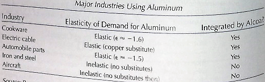

Source: Perry(1980).